# MTH6139 Time Series

Coursework 1 – Prophet Forecasting Analysis

Sarth Rahul Kavdikar

March 14, 2026

# 1 Introduction

Time series forecasting is a common technique used in economics, business, and environmental science for prediction purposes. In this project, a classical time series dataset is used, and the Prophet time series forecasting system developed by Meta is employed for the purpose of prediction.

Prophet is a procedure for forecasting time series data with long-term trends and seasonalities that is simple to use.

In this project, the time series dataset used is the **AirPassengers dataset**.

# 2 Dataset Description

The dataset contains monthly passenger counts for international airline travel between 1949 and 1960.

```r
data(AirPassengers)

start(AirPassengers)
```

```
## [1] 1949    1
```

```r
end(AirPassengers)
```

```
## [1] 1960   12
```

```r
frequency(AirPassengers)
```

```
## [1] 12
```

The series contains 144 observations with a frequency of 12, indicating monthly data.

# 3 Exploratory Analysis

We first visualise the time series to understand its structure.

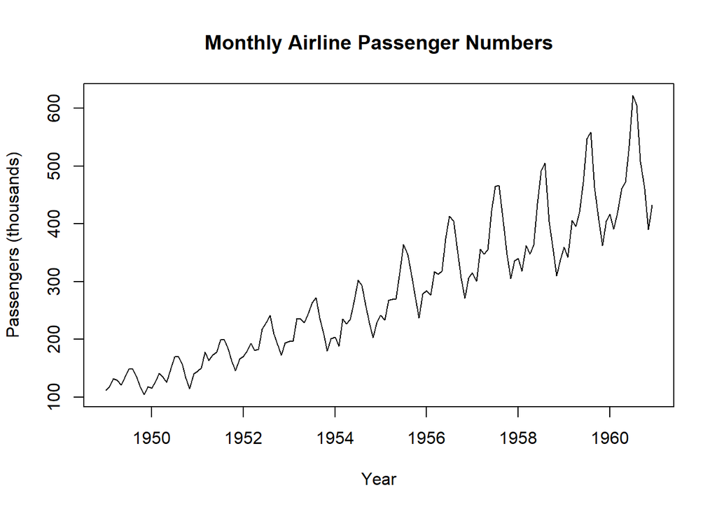

```r
plot(AirPassengers,
     main="Monthly Airline Passenger Numbers",
     xlab="Year",
     ylab="Passengers (thousands)")
```

The plot reveals two important characteristics:

- A strong upward trend over time
- Increasing seasonal fluctuations

The seasonal pattern suggests that passenger numbers increase during certain months of the year.

# 4 Variance Stabilisation

The variability of the data increases as passenger numbers grow. To stabilise the variance we apply a logarithmic transformation.

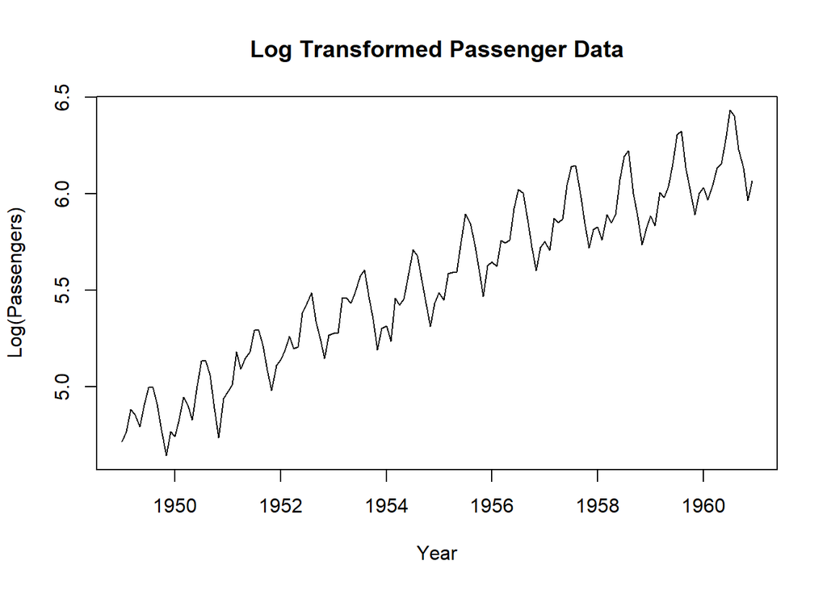

```r
log_passengers <- log(AirPassengers)

plot(log_passengers,
     main="Log Transformed Passenger Data",
     xlab="Year",
     ylab="Log(Passengers)")
```

The transformation reduces the increasing spread of the data and helps produce a more stable time series.

# 5 Preparing Data for Prophet

Prophet requires a dataframe with two columns named **ds** (date) and **y** (value).

```r
library(prophet)
library(zoo)
time_values <- time(AirPassengers)

date_values <- as.Date(as.yearmon(time_values))

passenger_dataframe <- data.frame(
  ds = date_values,
  y = as.numeric(AirPassengers)
)

head(passenger_dataframe)
```

```
##           ds   y
## 1 1949-01-01 112
## 2 1949-02-01 118
## 3 1949-03-01 132
## 4 1949-04-01 129
## 5 1949-05-01 121
## 6 1949-06-01 135
```

# 6 Prophet Forecasting Model

We now estimate a Prophet forecasting model using the passenger data.

```r
prophet_model <- prophet(passenger_dataframe)
```

```
## Disabling weekly seasonality. Run prophet with weekly.seasonality=TRUE to override this.
```

```
## Disabling daily seasonality. Run prophet with daily.seasonality=TRUE to override this.
```

The model automatically estimates trend and seasonal effects.

# 7 Forecasting Future Passenger Numbers

We generate predictions for the next 24 months.

```r
future_dates <- make_future_dataframe(prophet_model,
                                      periods = 24,
                                      freq = "month")

forecast_results <- predict(prophet_model, future_dates)

head(forecast_results)
```

```
##           ds    trend additive_terms additive_terms_lower additive_terms_upper
## 1 1949-01-01 107.8473    -21.2774203          -21.2774203          -21.2774203
## 2 1949-02-01 109.9819    -29.9397070          -29.9397070          -29.9397070
## 3 1949-03-01 111.9100     -0.4437455           -0.4437455           -0.4437455
## 4 1949-04-01 114.0446     -4.8747224           -4.8747224           -4.8747224
## 5 1949-05-01 116.1104     -3.6060409           -3.6060409           -3.6060409
## 6 1949-06-01 118.2451     34.3718704           34.3718704           34.3718704
##        yearly yearly_lower yearly_upper multiplicative_terms
## 1 -21.2774203  -21.2774203  -21.2774203                    0
## 2 -29.9397070  -29.9397070  -29.9397070                    0
## 3  -0.4437455   -0.4437455   -0.4437455                    0
## 4  -4.8747224   -4.8747224   -4.8747224                    0
## 5  -3.6060409   -3.6060409   -3.6060409                    0
## 6  34.3718704   34.3718704   34.3718704                    0
##   multiplicative_terms_lower multiplicative_terms_upper yhat_lower yhat_upper
## 1                          0                          0   59.20008   115.9395
## 2                          0                          0   52.03125   108.1210
## 3                          0                          0   84.87915   140.3400
## 4                          0                          0   80.41623   137.4957
## 5                          0                          0   83.95233   142.8517
## 6                          0                          0  124.73955   180.7018
##   trend_lower trend_upper      yhat
## 1    107.8473    107.8473  86.56984
## 2    109.9819    109.9819  80.04221
## 3    111.9100    111.9100 111.46624
## 4    114.0446    114.0446 109.16992
## 5    116.1104    116.1104 112.50439
## 6    118.2451    118.2451 152.61695
```

# 8 Forecast Visualisation

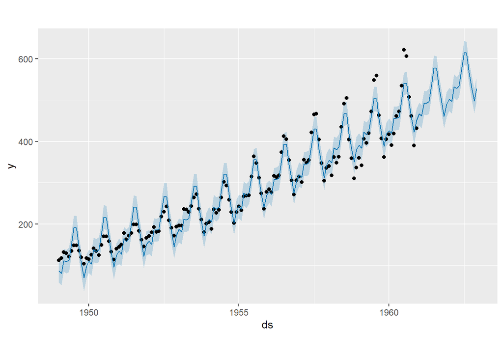

```r
plot(prophet_model, forecast_results)
```

The plot displays the predicted passenger counts along with uncertainty intervals.

The forecast suggests continued growth in international airline travel.

# 9 Model Components

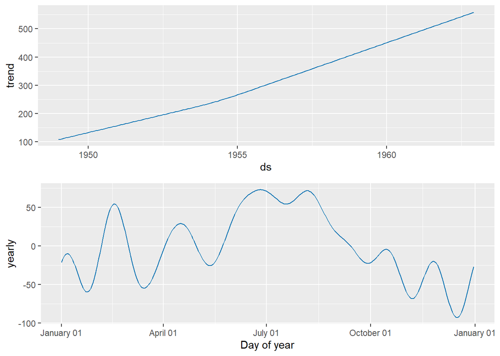

```r
prophet_plot_components(prophet_model, forecast_results)
```

The model separates the series into:

- Long-term trend
- Seasonal component

The seasonal component highlights recurring yearly travel patterns.

# 10 Conclusion

In this project, we worked with airline passenger data. The data shows strong growth trends that are characteristic of transportation demand.

The data has been successfully modelled with the trend as well as the seasonality. The data is showing a trend that the number of passengers will continue to grow based on the current trends.

This is a practical example of how we can use current forecasting tools to work with time-series data.

# References

Prophet Documentation  
https://facebook.github.io/prophet/

R Markdown Guide  
https://rmarkdown.rstudio.com